# Probability via Simulation

Albert Y. Kim

Mon Oct 31, 2016

```r
library(dplyr)
library(ggplot2)
library(mosaic)
```

- LC1: Create a histogram of the number illustrating the long-run behavior of flipping a coin 10 times.
  - Where is it centered?
  - Describe the shape of the **distribution** of values
- LC2: Tie all elements of Line 13 of code below to the Attributes of Powerball seen in the slides above.
- LC3: Try to replicate the above, but for the sum of two die rolls. Hint: `resample(c(1:6), 2)`

## LC1

```r
coin_flips <- do(500)*rflip(10)
coin_flips <- coin_flips %>%
  as_data_frame()
```

If we `View(coin_flips)` the first 6 rows, we see that we have in **tidy format**:

| n | heads | tails | prop |
| --- | --- | --- | --- |
| 10 | 4 | 6 | 0.4 |
| 10 | 6 | 4 | 0.6 |
| 10 | 3 | 7 | 0.3 |
| 10 | 4 | 6 | 0.4 |
| 10 | 6 | 4 | 0.6 |
| 10 | 5 | 5 | 0.5 |

So we plot a histogram of the `heads` variable with `binwidth=1` since we are dealing with integers i.e. whole numbers.

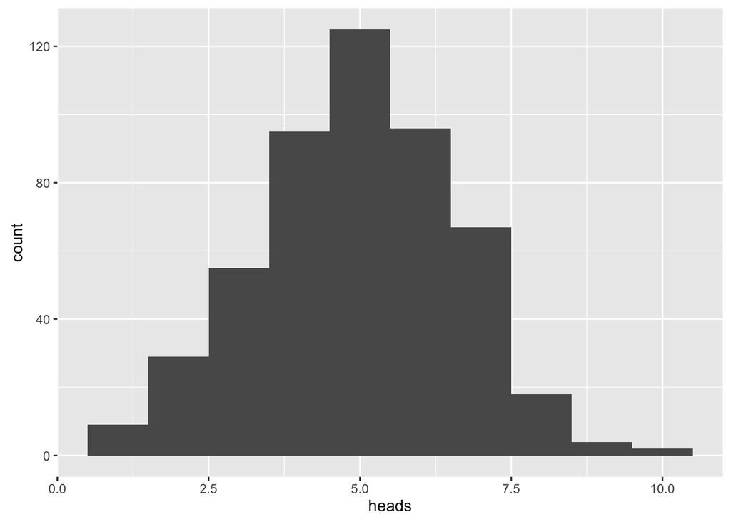

```r
ggplot(coin_flips, aes(x=heads)) +
  geom_histogram(binwidth = 1)
```

- Where is it centered? Answer: At 5 i.e. half of 10.
- Describe the shape of the **distribution** of values. Answer: bell-shaped. i.e. like a Normal distribution.

## LC2

- Atrributes of the Lottery Machine:
  - How many balls do you have? **2**
  - What are written on the balls? **Heads and tails**
  - Do the balls have equal probability of being picked? **Yes**
- Attributes of the Drawing:
  - How are you drawing the balls? **At random**
  - How many balls do you draw? **10**
  - What are you recording about each drawn ball? **If the ball has heads or tails**
  - What do you do with drawn balls? **You put them back in the machine**
- Number of Lotteries:
  - How many times do you repeat the lottery? **Many many many times. In the above case, 500 times**

## LC3

Let’s unpack `sample(c(1:6), 2)`:

```r
two_dice <- do(500) * sample(c(1:6), 2)
two_dice <- two_dice %>%
  as_data_frame()
```

If we `View(two_dice)` the first 6 rows, we see that we have in **tidy format**:

| V1 | V2 |
| --- | --- |
| 6 | 3 |
| 6 | 5 |
| 4 | 1 |
| 2 | 3 |
| 6 | 1 |
| 3 | 5 |

So to get the sum of the two dice, we `mutate()` a new variable `sum` based on the sum of the two die:

```r
two_dice <- two_dice %>%
  mutate(sum = V1 + V2)
```

| V1 | V2 | sum |
| --- | --- | --- |
| 6 | 3 | 9 |
| 6 | 5 | 11 |
| 4 | 1 | 5 |
| 2 | 3 | 5 |
| 6 | 1 | 7 |
| 3 | 5 | 8 |

And now we plot it:

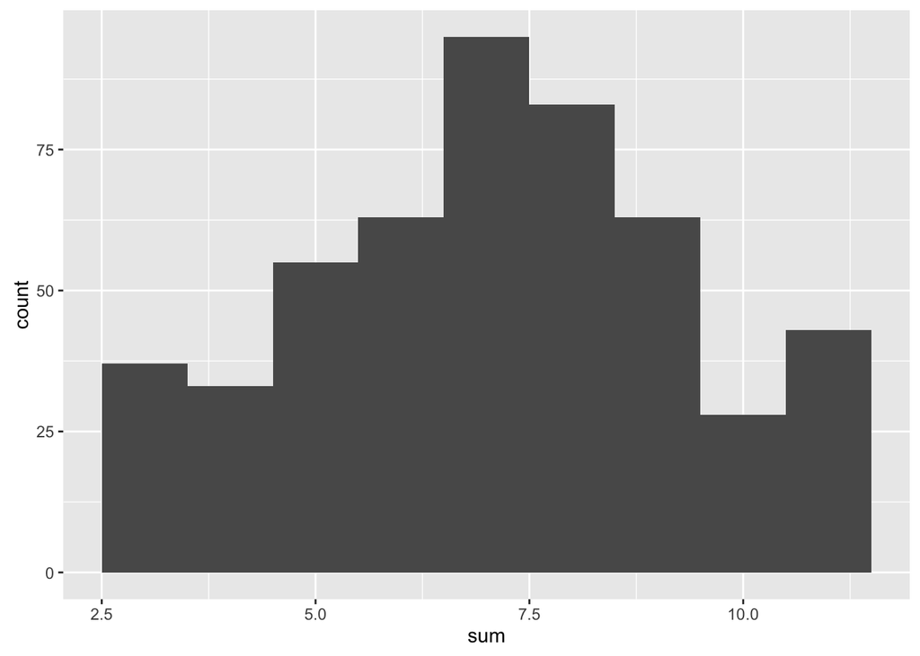

#### Advanced

What’s the deal with the ugly axes tick marks? This is again b/c computers are stupid, and ggplot does not know we are dealing only with whole numbers i.e. integers. We could cheat it and treat the sum, a numerical variable, as a categorical variable using `geom_bar()`

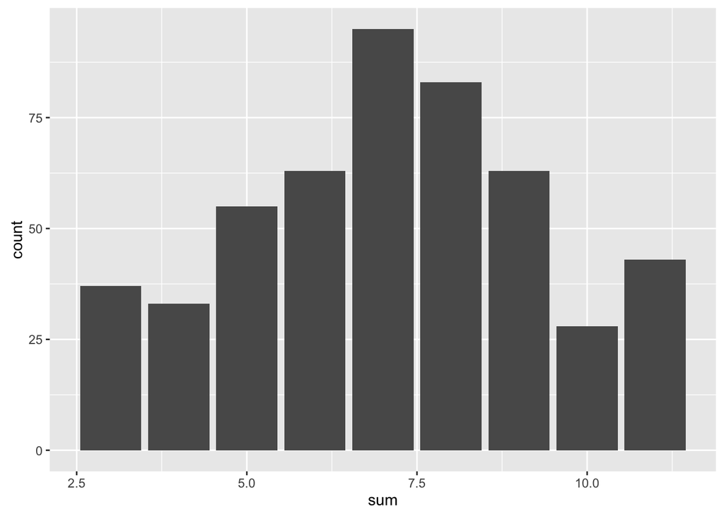

Here we can at least separate out the individual whole numbers, but we still have the axes tick marks problem? How do I fix these? That’s for the more advanced data science class [MATH 216 Data Science](https://rudeboybert.github.io/MATH216/).